# Exploratory Analysis

Natalie Olson, Caleb Hur, Kazuma Itagaki, Gulnoor Brar

02/18/2023

## Project title

### Authors

Natalie Olson (ngo610@uw.edu)

Gulnoor Brar (gul2002@uw.edu)

Caleb Hur (calebhur@uw.edu)

Kazuma Itagaki (kazita03@uw.edu)

### Date

Winter 2023

### Abstract

For our project, we’re seeking to answer what elements of a horror movie and its production contribute the most to its success. Media’s effect on the population is often overlooked, but popular movie trends can say a lot about modern culture. We’re interested in studying what patterns and trends influence a horror movie’s success the most and how that impacts its viewers.

### Keywords

Horror movies, media, pop culture, ratings, film

### Introduction

Our project seeks to explore popular trends in horror movie data through analyzing the elements that make up the most successful horror movies. We hope to discover:

Do certain actors and cast members draw more viewers to horror movies?

How big of a role does budget play in determining the success of a horror movie?

Where are most horror movies filmed? How does this impact the overall success of the movie?

How do all of these elements (budget, filming location, subgenre, director, etc) interact with each other and affect the movies’ IMBD ratings? What kinds of patterns can be found here?

How can data science can applicable to studying entertainment and the effects of media on society?

Media has an undervalued yet crucial impact on people and society; movies, in particular, directly reflect modern culture and provide important thought around the past, present, and future. Our project seeks to connect our personal interests to data science, asking what we can learn from data science about a completely different field like entertainment. In addition, we hope our findings can also be interesting to anyone who is interested in media and film or data science. Our project will base our analysis on data provided by Tidy Tuesday and taken from IMDB.

### Related Work

We are interested in horror movies, more specifically “why horror movies”. There are many aspects to horror movies/shows, including the cast, director, location, subgenre, runtime, and the type of horrors they have. We want to dissect what makes the best horror movies, including all of these aspects, so in the end we could have an answer to the question “What would be the most successful horror movie/show?”.While it may not be the most realistic and definitive answer, we believe it could point us into the direction of it, and still shine light on the type of horror movies/shows that are regarded as the best. There are some related works, in which horror and its psychological impacts are discussed and studied, Also an article which discusses the topic of why do we enjoy horror genre, These are cited below:

Nummenmaa, L. (2021, March 4). Psychology and neurobiology of horror movies. https://doi.org/10.31234/osf.io/b8tgs

Paul Bloom, The Paradox of Pleasurable Fear, Trends in Cognitive Sciences, Volume 25, Issue 2, 2021, Pages 93-94, ISSN 1364-6613, https://doi.org/10.1016/j.tics.2020.12.001.(https://www.sciencedirect.com/science/article/pii/S1364661320302965)

Coolidge, F. L., Ph.D. (2021, October 23). Why We Enjoy Horror Films. Psychologytoday.com. Retrieved February 1, 2023, from Why We Enjoy Horror Films | Psychology Today

These works go into the details of why the mind likes horror movies, its because of its fear behind a screen, There is a sort of thrill in feeling a bit uneasy and unsafe because we live in a much safer society than we used to. They also go over Sigmund Freud and David Hume’s theories, about repressed emotions being released being therapeutic and people engaging in acts that scare them, make them sad, make them regret. While these judge the philosophically and psychological side of this genre, we could not find many articles statistically covering this.

### The Dataset

As for questions of power, IMDB has an agenda to push their ratings in favor of any partnerships they may have. Furthermore, advertisements are at the forefront of their business model, so IMDB is susceptible to bias and manipulation.

One possible limitation with this data is on the collection method of viewer ratings. We are testing the success of each horror film with its viewer response, which is a highly fluctuating and variable number. There are a multitude of factors that could impact a person’s score for a movie: when they watched it, why they watched it, who they watched it with, whether they knew spoilers, among many other factors. These variables are impossible to accurately measure, and IMDB does not bother with discovering any underlying reasons for a viewer’s rating; they are only concerned with a number. Therefore, when considering our findings, we must remember that the feature (viewer ratings) we are testing a movie’s success against is not clear-cut.

### Implications

As we are able to answer our research questions, our data analysis will help with understanding what makes a successful horror movie. Since most of the data sets categories are objective, we are able to make a template or a reference of what makes a good horror movie. People who are interested in creating a new horror movie can refer to our project to see what exactly made a horror movie good (length, language, etc.). Another implication from our research is how we analyze the data set. Since we are looking at what makes something successful, another implication is that people can look at our project and see how we compared different movies and use that to compare other forms of media such as songs, shows, books, etc. Since comparing different works within genres is very common, our project would be a very good reference for those who want to compare works in the future.

### Limitations & Challenges

Some challenges we might face during the project is that since we are working with movies and how successful they are, the success of movies may be objective, but the reason behind their successes can be subjective. Why does one like a horror movie more than another? That is probably a subjective answer rather than an objective one. Though having a big data set that can help avoid that since it provides us with data that people have voted on and can agree on. Another challenge we may have with our project is that though we are looking into horror movies, there are also many different kinds of horror movies. Horror movies may be a subgroup of the movie category, even within the horror movie category there are more subcategories like jump scares, suspense, and such. Sometimes, it’s hard to compare these mini subcategories if they are too different from one another, like comparing an apple to a pencil (obviously an exaggerated comparison), two different things.

### Summary Information

Our horror movie dataset included **3328** different horror movies with release dates ranging from **2012-01-01** to **2017-10-31**. Out of all **3328** horror movies, **Bonehill Road (2017)** was the highest rated movie with a rating of **9.8**, and **Countrycide (2017)** and **Una Comedia Macabra (2017)** were the lowest rated movies with a rating of only **1** out of 10. Although **Maldives** was the country with the highest average rating, the highest rated movie was released in the **USA**, being **Bonehill Road (2017)**. While we are looking in particular at horror movies, many of these movies have multiple sub genres, such as Thriller or Drama, but the sub-genre with the highest rating on average was surprisingly **Animation**.

### Table

Top 10 Most Highly Rated Horror Movies in the USA

| Review Rating | Title | Release Date | Release Country |
| --- | --- | --- | --- |
| 9.8 | Bonehill Road (2017) | 27-Oct-17 | USA |
| 9.6 | The Theta Girl (2017) | 13-Oct-17 | USA |
| 9.5 | Flesh of the Void (2017) | 21-Oct-17 | USA |
| 9.4 | Bong of the Living Dead (2017) | 20-Oct-17 | USA |
| 9.3 | Take 2: The Audition (2015) | 1-Feb-15 | USA |
| 9.3 | Johann Karlo’s Gun Driver (2016) | 1-Sep-16 | USA |
| 9.2 | Barrio Tales 2 (2016) | 2016 | USA |
| 9.2 | Hell Mountain (2016) | 2016 | USA |
| 9.1 | The Plague 2: Biohazard Blood (2017) | 11-Jun-17 | USA |
| 9.1 | Do You See Me (2017) | 20-May-17 | USA |

### Chart 1

We thought of this plot because we wanted to check our hypothesis, about the movies being rated best, or the best rated movies being around Halloween. The data confirms that hypothesis, with October being the best month in the year to release a horror movie. This spot is right before Halloween. The worst time would be around January and march. this is also right at the opposite end of the year from Halloween. One could either argue there is a bias around Halloween, or that we generally feel more afraid around it.

Aside from this there were some movies which did not have a specific month with them, these were excluded from the data.

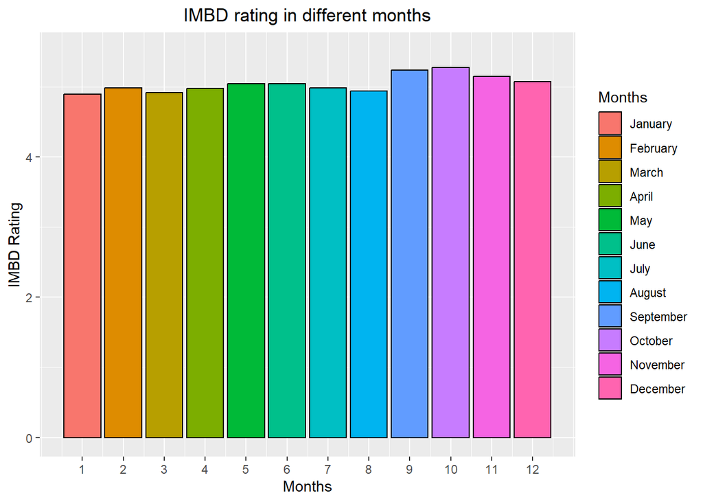

### Chart 2

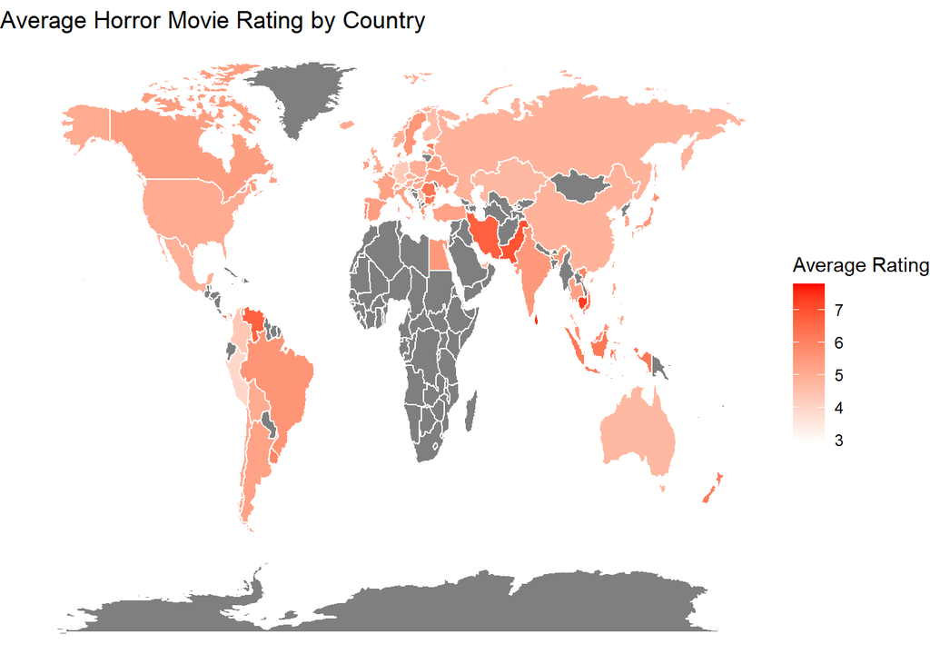

### Chart 3

The scatter plot below represents how a movie’s production budget determines its success in theaters. As seen below, the correlation between the two features proves to be inconclusive. There are great clusters at $500,000; $1,000,000; and $1,500,000 as many producers round their expenses to the simplest value; as a result, the data is severely limited and does not accurately represent the production budget. Nevertheless, the data that clusters near $10,000 varies greatly and shows that many films seem to perform incredibly well or dismally poor regardless of their budget. One could conclude budget has no effect on a film’s success and other features must play a larger role. (I would have ideally made a box and whiskers plot to properly analyze the data, but I lacked the proper knowledge to do so.) It should be noted that there were thousands of films with no budget data and were unincluded. Furthermore, the most recent exchange rates of each budget was used, as not every exchange rate was in terms of USD.

[figure not shown]